# TPRS Poisson Regression

Samuel Herold, Kayleigh Keller

This simulation looks at the effectiveness of varying degrees of freedom (up to 100) of Thin Plate Regression Splines as basis functions in a Poisson Regression to try to remove spatial confounding. The true b1 of x is 1, and is our target. Samples of size 1000 were taken 50 times. 4 experiments were ran with different density of the base gp surface and the confounding service (combinations of .1 and .25).

# Trial 1

```
## [1] "X created using a spectral density of: 0.25. Confounder created using a spectral density of: 0.1."
```

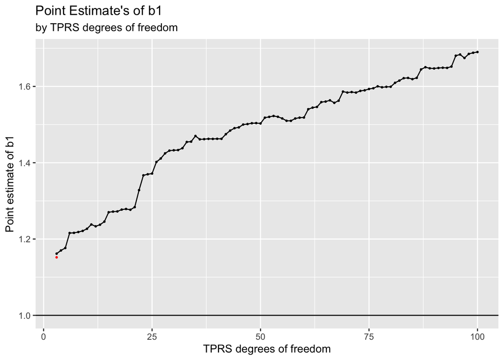

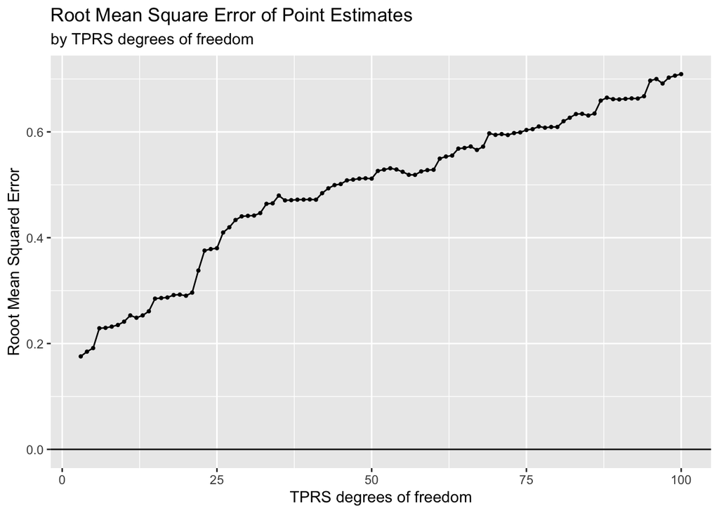

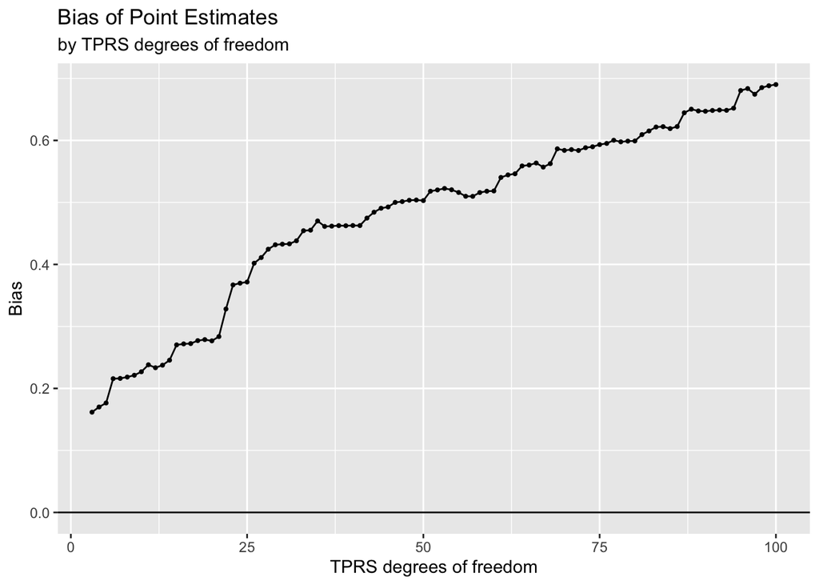

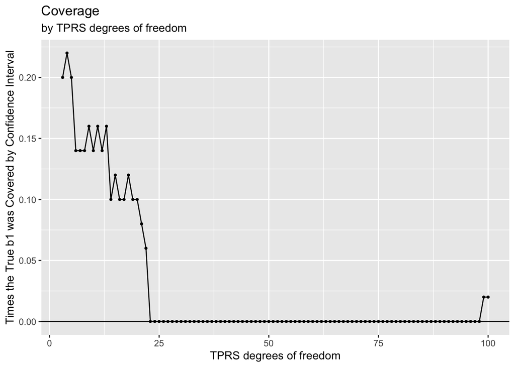

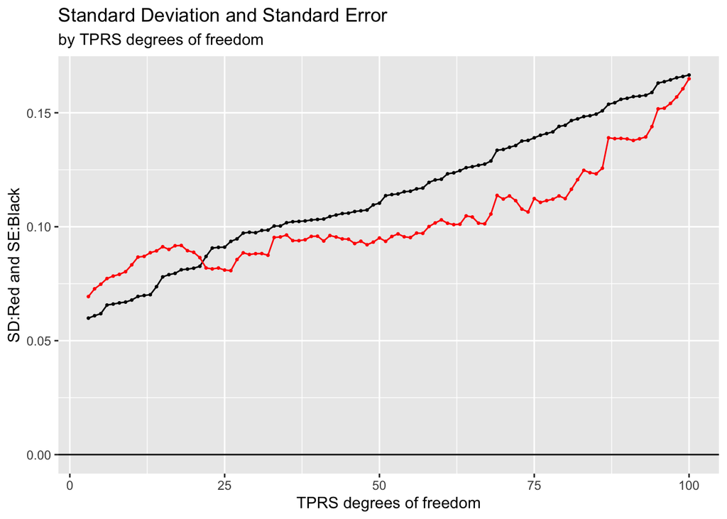

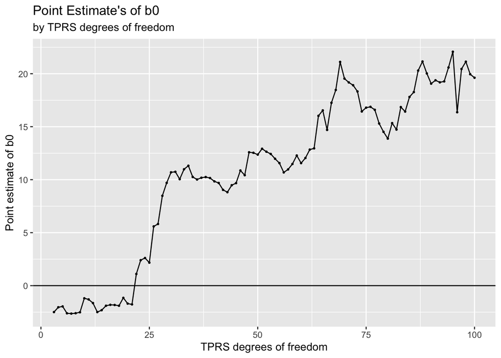

# Trial 2

```
## [1] "X created using a spectral density of: 0.1. Confounder created using a spectral density of: 0.1."
```

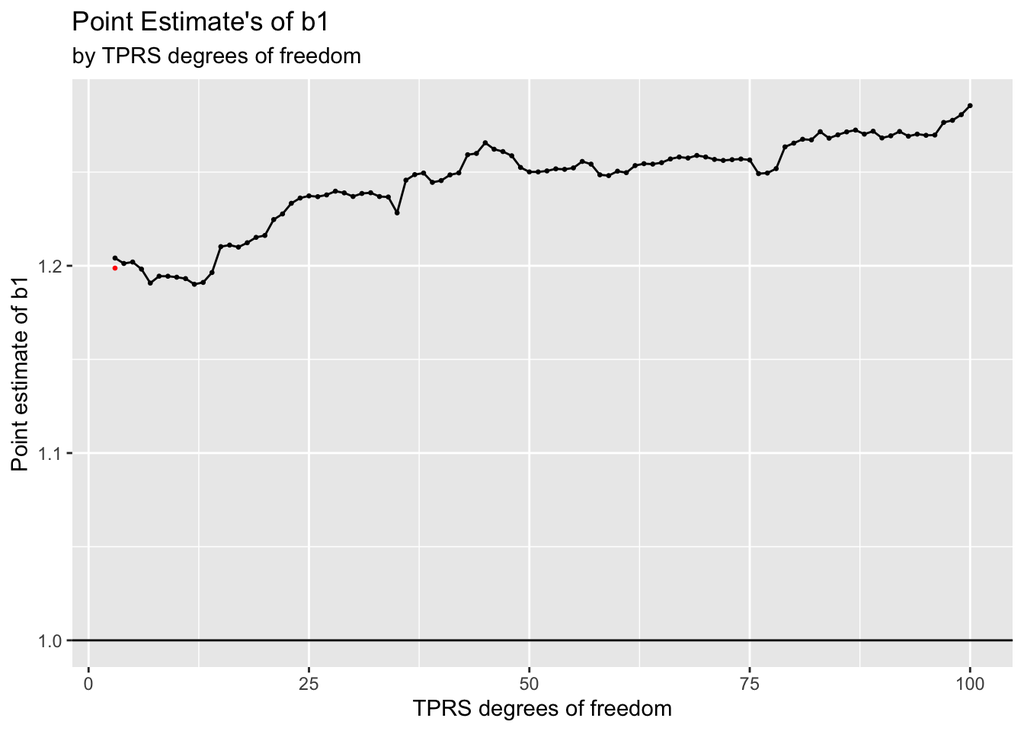

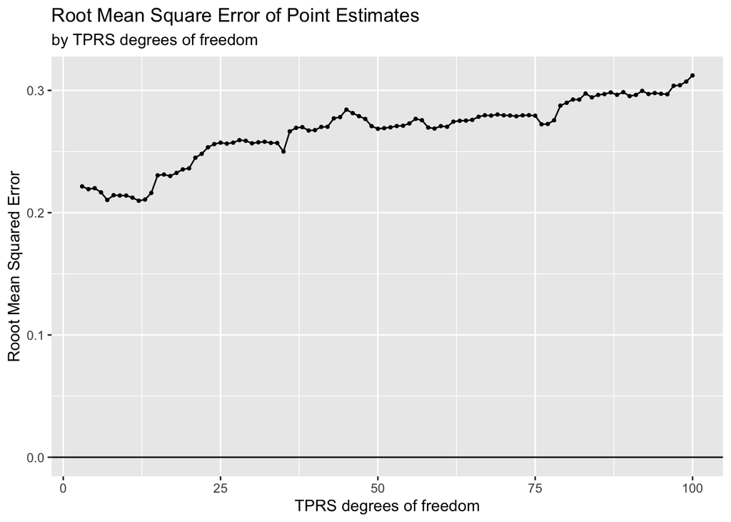

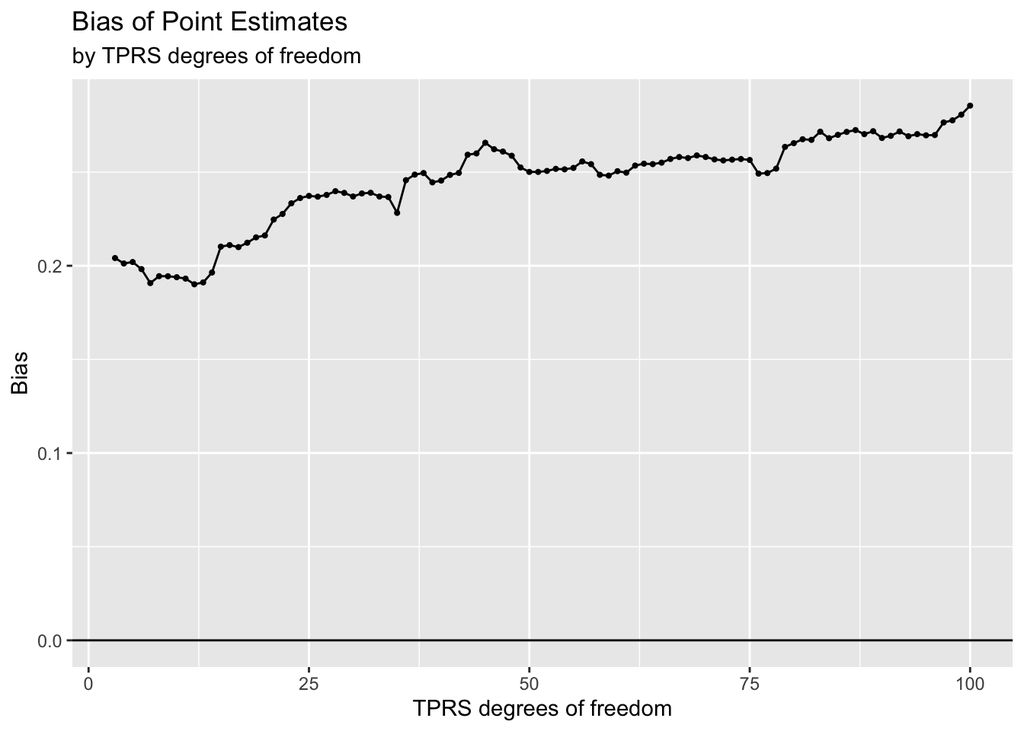

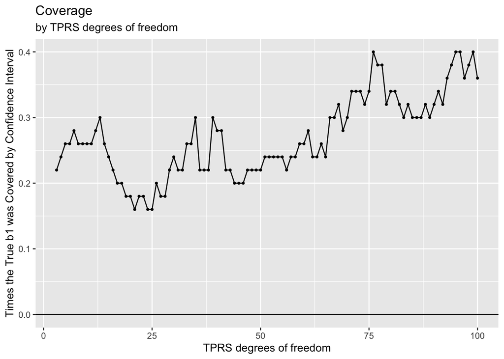

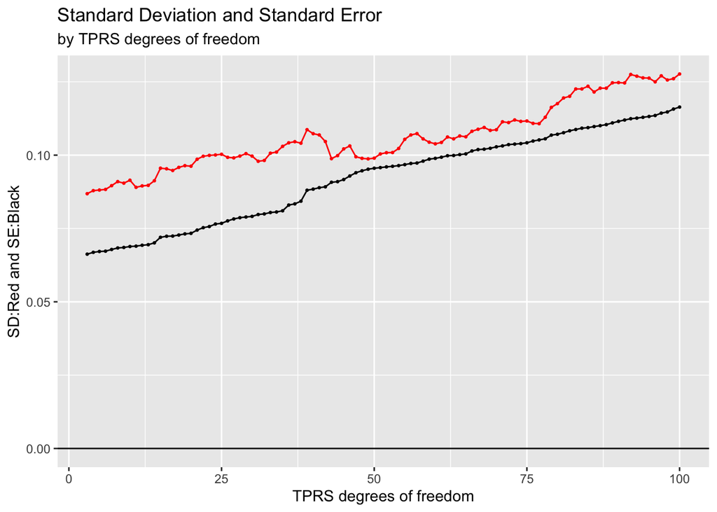

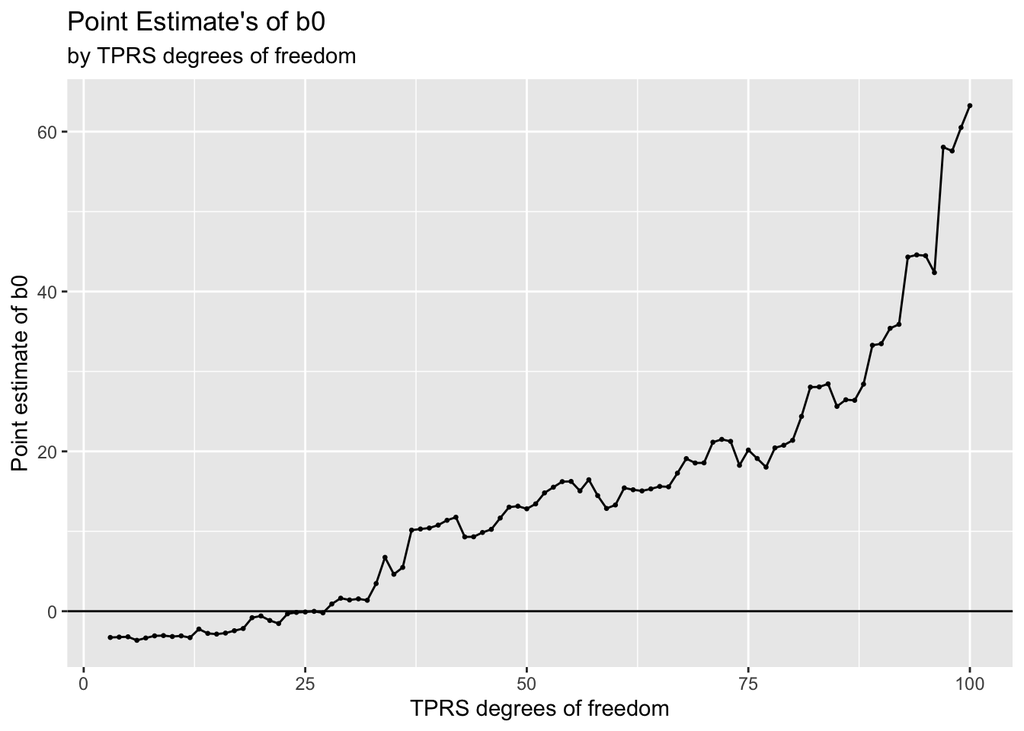

# Trial 3

```
## [1] "X created using a spectral density of: 0.25. Confounder created using a spectral density of: 0.25."
```

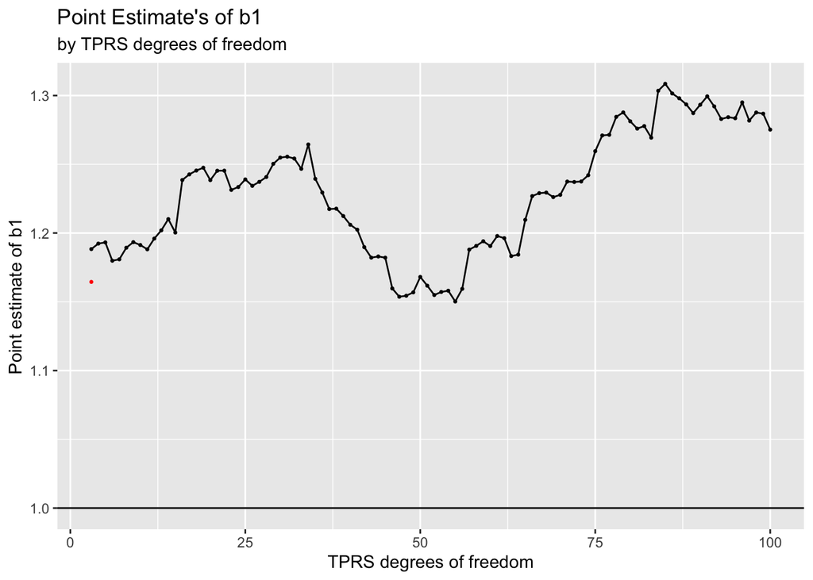

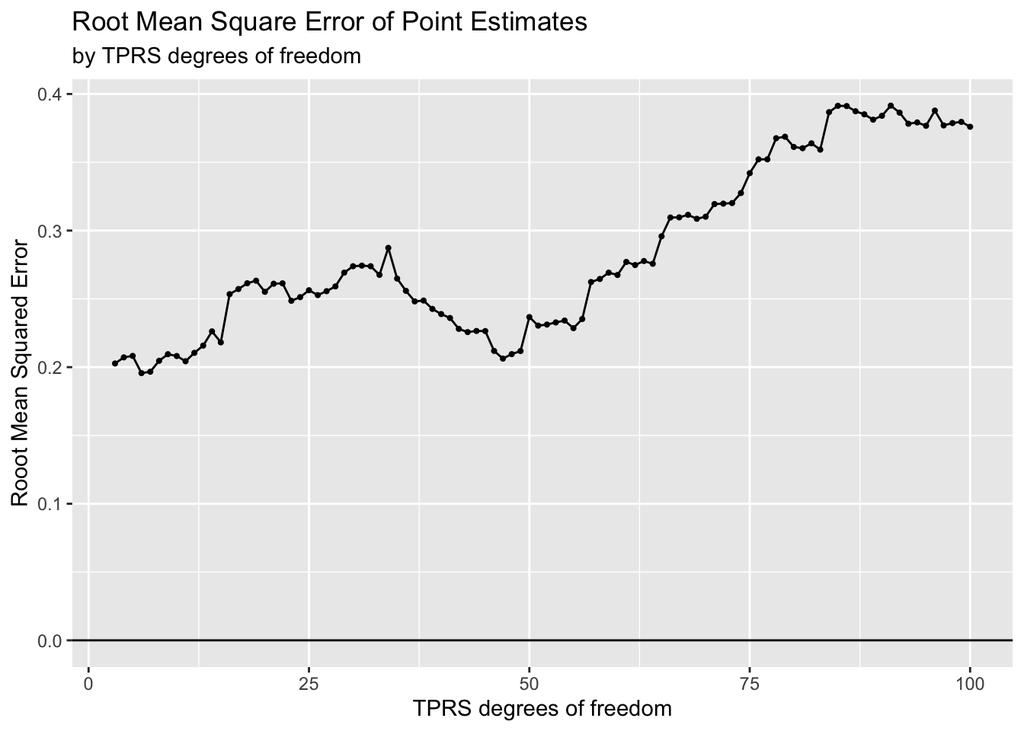

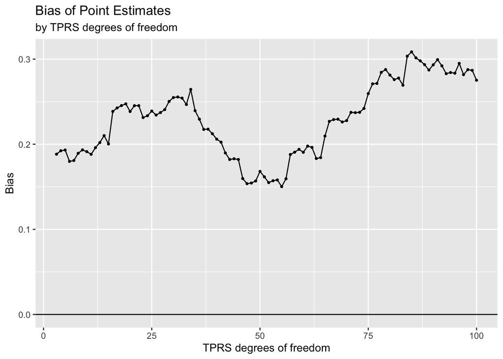

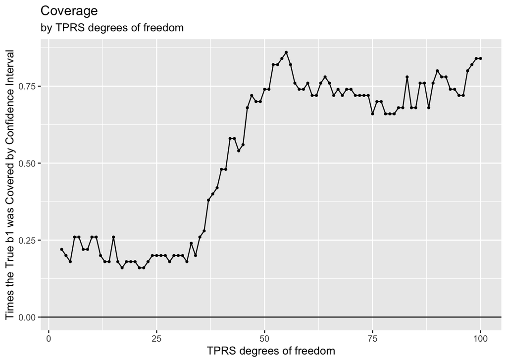

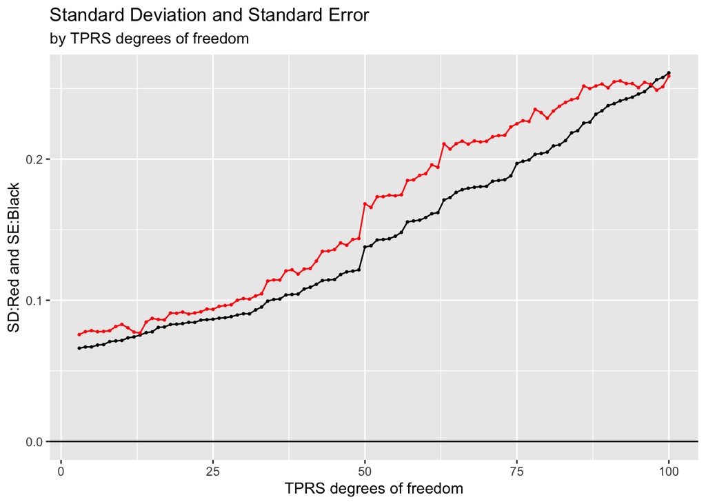

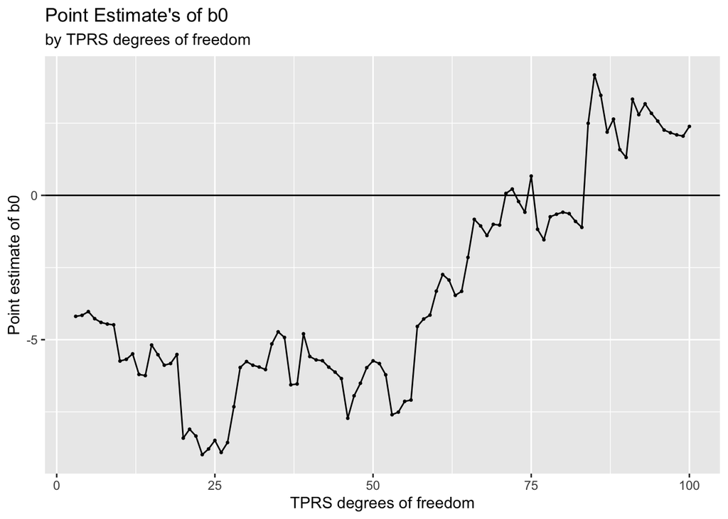

# Trial 4

```
## [1] "X created using a spectral density of: 0.1. Confounder created using a spectral density of: 0.25."
```

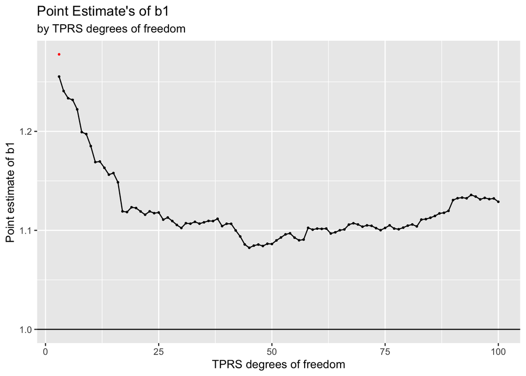

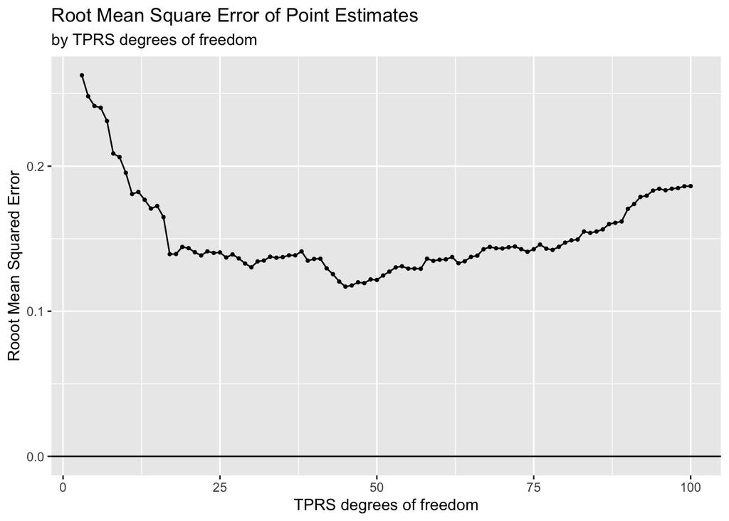

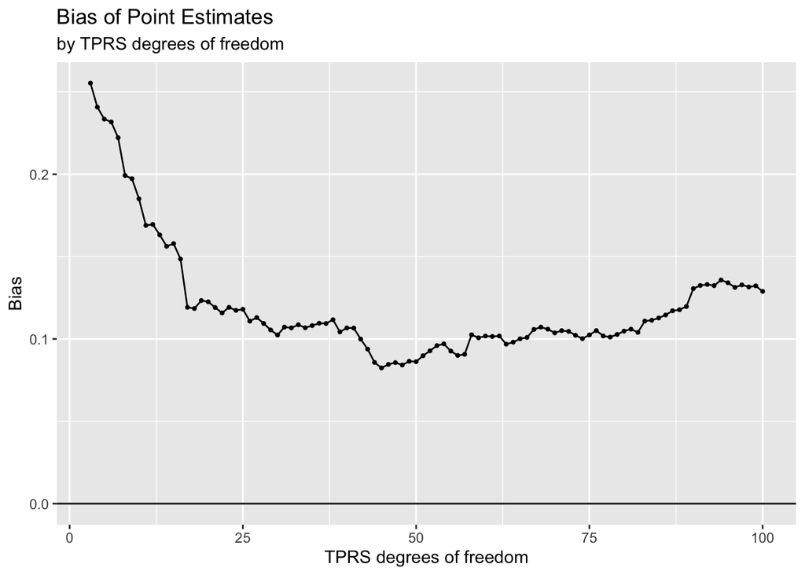

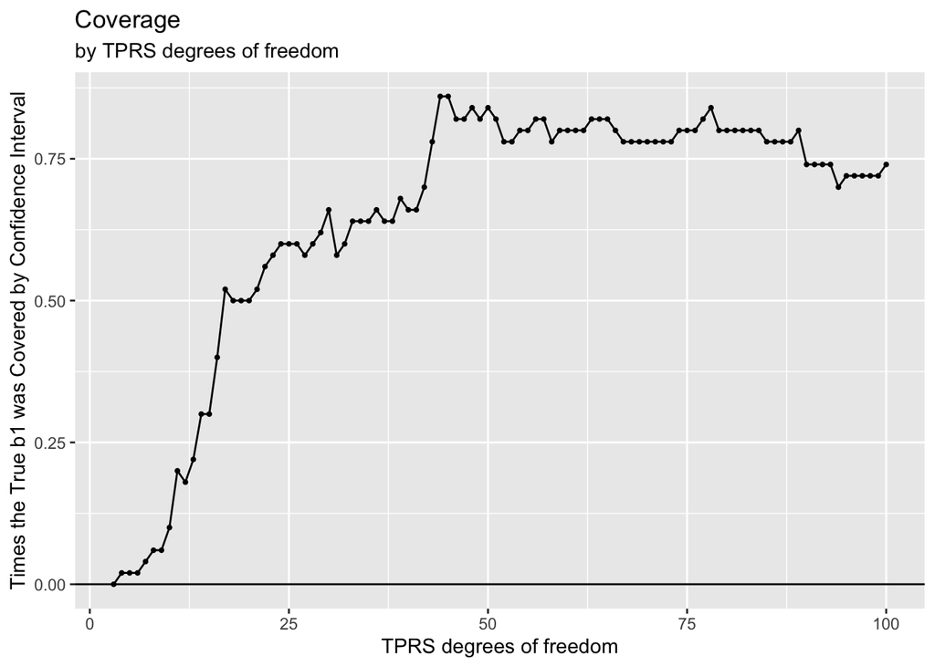

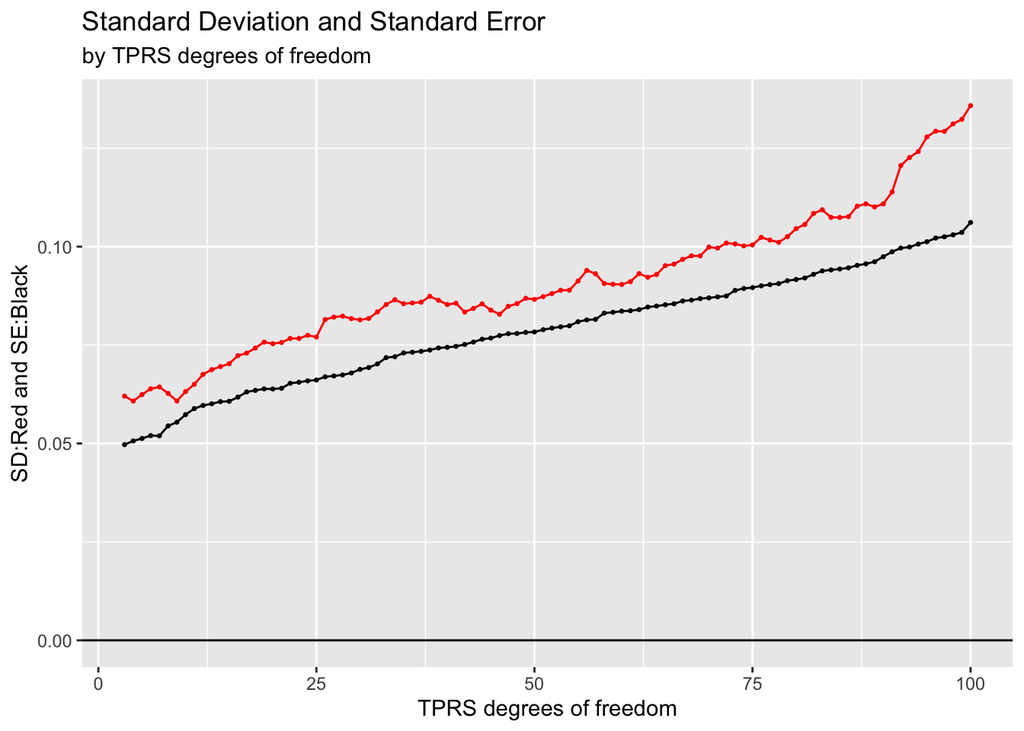

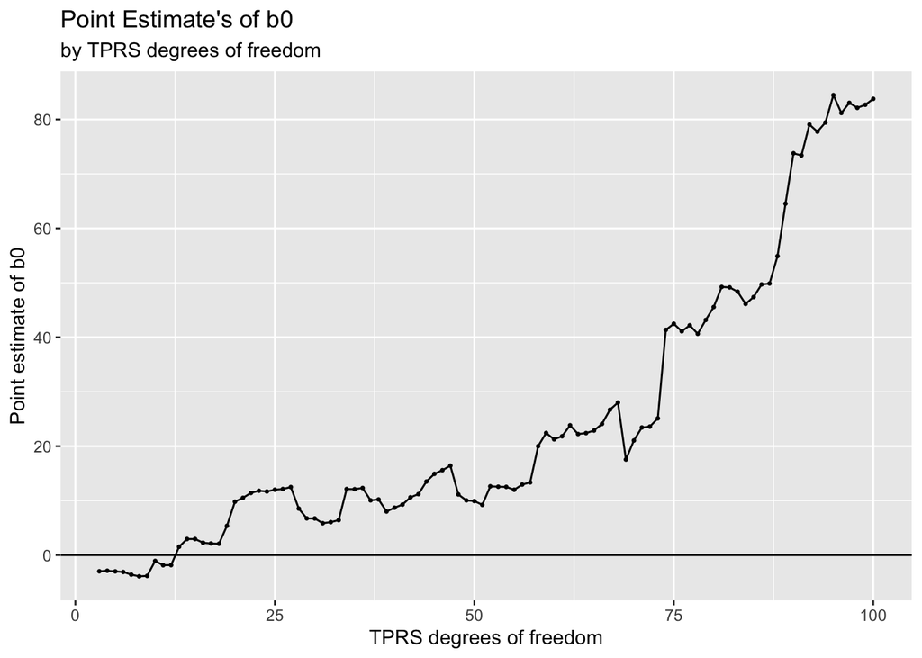

TPRS’s appear to not be effective in poisson regression. For 3/4 situations, the b1 estimate is almost always larger than than it would be if we didn’t add TPRS’s (seen in red on “Point Estimate of b1”). Only when the confounder has a higher density setting do they seem effective (g = .1, c = .25). Every other model with TPRS does worse than the model with no TPRS. At very best it will do slightly better at one or two specific degrees of freedom. SD and SE increase together. Also, in most trials, b0 skyrockets with more degrees of freedom.